# SHAP-Based Explainability for Time-to-Event Models

ml4time2event

2025-11-02

# Introduction

This vignette demonstrates how to use SHAP (SHapley Additive exPlanations) analysis with ml4time2event pipelines to explain predictions from survival and competing risks models.

## What is SHAP?

SHAP values provide a unified measure of feature importance that explains individual predictions. For any prediction, SHAP values show:

- Which features contributed most to the prediction
- Whether each feature increased or decreased the predicted risk
- How features interact with each other

SHAP values satisfy an important property:
$$\text{Prediction} = \text{Baseline} + \sum_{i}
\text{SHAP}_i$$

where the baseline is the average prediction across all observations.

## Why SHAP for Time-to-Event Models?

Time-to-event models predict survival curves or cumulative incidence functions (CIFs), which are complex outputs. SHAP requires scalar predictions, so we use **expected time lost** as our target metric:

- **Expected time lost** = integral of event probability from 0 to time horizon
- For survival: integral of $1 - S(t)$ from 0 to $T$
- For competing risks: integral of CIF from 0 to $T$

This gives an interpretable scalar: the expected amount of time lost to the event by time $T$.

# Setup

```r
library(ml4time2event)
library(dplyr)
library(ggplot2)

# Required for SHAP calculation
# install.packages("fastshap")  # or kernelshap
library(fastshap)

# Set random seed for reproducibility
set.seed(42)
```

# Example 1: Survival Analysis with Lung Cancer Data

## Fit a Survival Pipeline

First, we’ll fit a survival model using the lung cancer dataset:

```r
# Load lung cancer data
lung_df <- get_lung_survival_data()

# Examine the data
head(lung_df)
```

```
##   time status age  sex ph.ecog ph.karno pat.karno  meal.cal   wt.loss age_group
## 1  306      1  74 Male       1       90       100 1175.0000  1.052921   Elderly
## 2  455      1  68 Male       0       90        90 1225.0000 15.000000   Elderly
## 3 1010      0  56 Male       0       90        90 1227.9846 15.000000    Middle
## 4  210      1  57 Male       1       90        60 1150.0000 11.000000    Middle
## 5  883      1  60 Male       0      100        90  970.0705  0.000000    Middle
## 6 1022      0  74 Male       1       50        80  513.0000  0.000000   Elderly
##   performance_good
## 1                1
## 2                1
## 3                1
## 4                1
## 5                1
## 6                0
```

```r
dim(lung_df)
```

```
## [1] 228  11
```

```r
# Fit pipeline with multiple models
surv_pipeline <- ml4t2e_fit_pipeline(
  data = lung_df,
  analysis_type = "survival",
  timevar = "time",
  eventvar = "status",
  models = c("coxph", "glmnet", "rulefit", "xgboost", "ttah"),
  include_rf = FALSE,
  prediction_times = seq(0, 1000, length.out = 50)
)
```

```
## Fitting ttah ...
## Fitting glmnet ...
## Fitting coxph ...
## Fitting rulefit ...
## Fitting xgboost ...
```

```r
print(surv_pipeline)
```

```
## ml4time2event Pipeline
## ======================
## Analysis type : survival
## Time variable : time
## Event variable: status
## Predictors    : 9 processed (9 original)
## Recipe        : minimal_data_recipe
## Observations  : 228
```

## Calculate SHAP Values

Now we calculate SHAP values for a subset of observations. We’ll use a 1-year time horizon (365 days):

```r
# Select observations to explain
explain_data <- lung_df[1:50, ]

# Calculate SHAP values
# Using nsim = 50 for speed; use higher (e.g., 100-200) for production
shap_surv <- ml4t2e_calculate_shap(
  pipeline = surv_pipeline,
  data = explain_data,
  time_horizon = 365,  # 1-year expected time lost
  nsim = 50
)

print(shap_surv)
```

```
## ml4time2event SHAP Analysis
## ============================
## Analysis type  : survival
## Time horizon   : 365
## Observations   : 50
## Features       : 9
## Baseline pred  : 115.801
##
## Features:
##   age
##   sex
##   ph.ecog
##   ph.karno
##   pat.karno
##   meal.cal
##   wt.loss
##   age_group
##   performance_good
```

## Variable Importance Plot

The importance plot shows which features have the biggest impact on predictions:

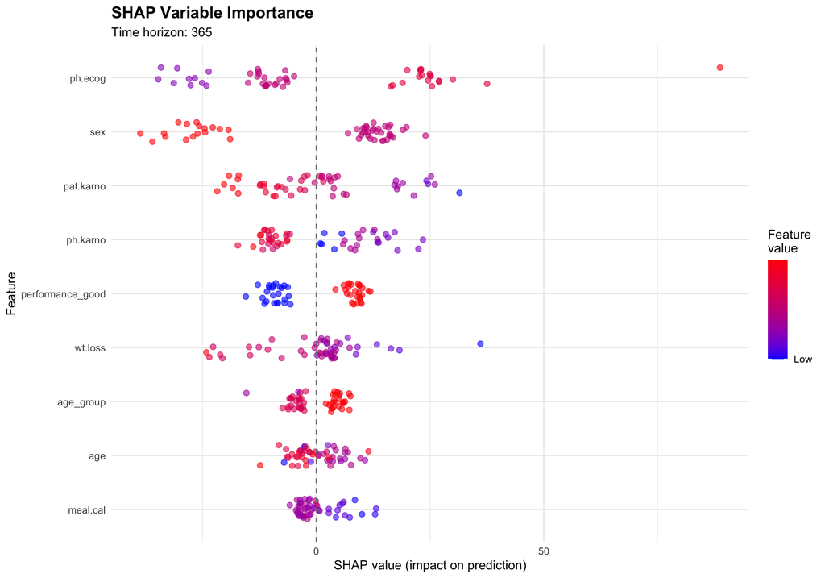

```r
# Create importance plot (beeswarm style)
ml4t2e_shap_importance(shap_surv, plot_type = "beeswarm")
```

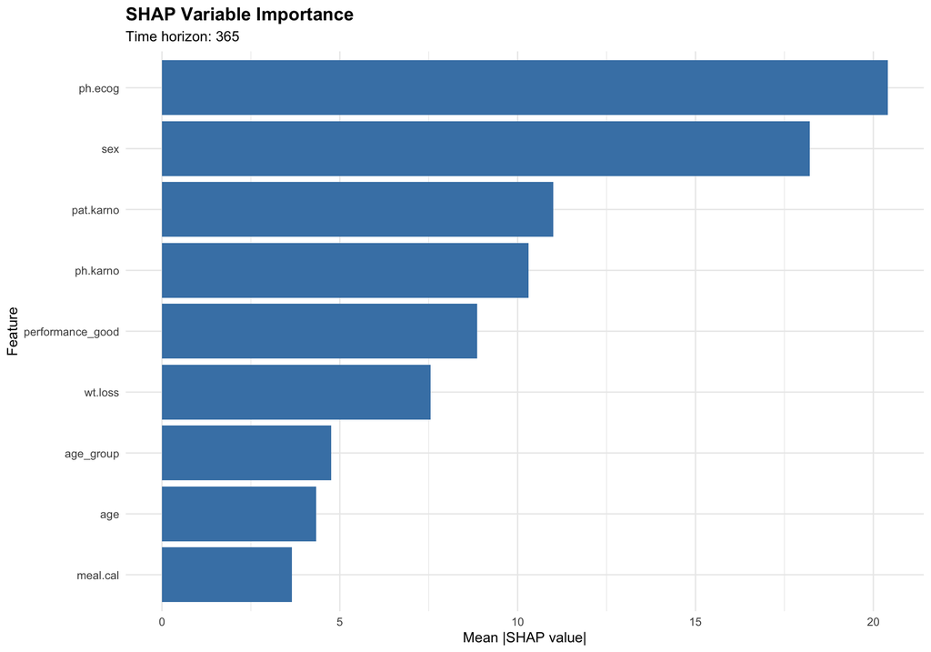

```r
# Alternative: bar plot
ml4t2e_shap_importance(shap_surv, plot_type = "bar", max_features = 10)
```

**Interpretation:** - Features are ranked by mean absolute SHAP value (average impact) - In beeswarm plots: - Each point is one observation - Red points = high feature value - Blue points = low feature value - Position on x-axis = SHAP value (contribution to prediction)

## Dependence Plots

Dependence plots show how a specific feature affects predictions:

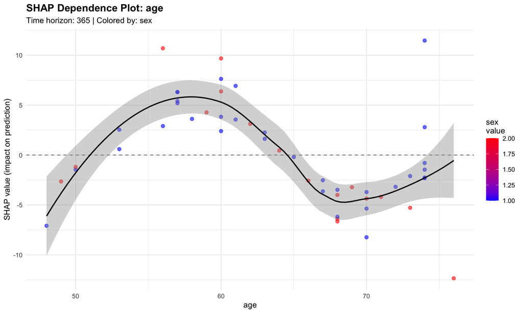

```r
# Dependence plot for age
# Automatically detects interactions with other features
ml4t2e_shap_dependence(shap_surv, feature = "age")
```

```r
# You can also specify which feature to use for coloring
if ("sex" %in% colnames(lung_df)) {
  ml4t2e_shap_dependence(shap_surv, feature = "age", color_by = "sex")
}
```

[figure not shown]

**Interpretation:** - X-axis: feature value - Y-axis: SHAP value (impact on expected time lost) - Color: value of interacting feature - Positive SHAP = increases expected time lost (worse prognosis) - Negative SHAP = decreases expected time lost (better prognosis)

## Waterfall Plot for Individual Predictions

Waterfall plots explain individual predictions:

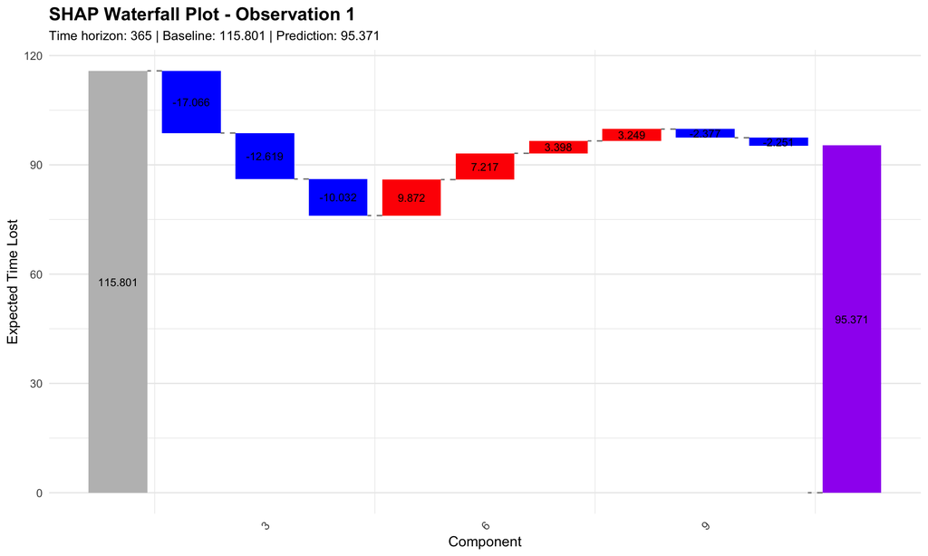

```r
# Explain the first observation
ml4t2e_shap_waterfall(shap_surv, obs_id = 1, max_features = 10)
```

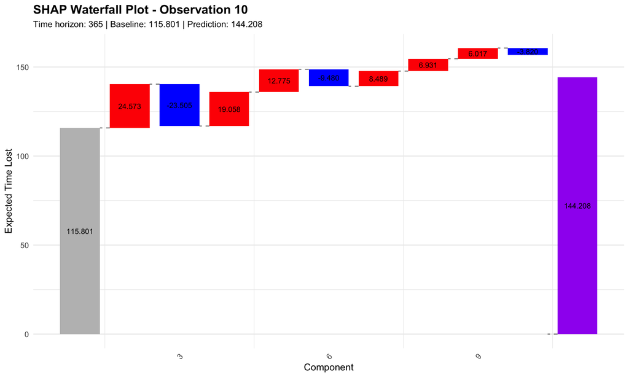

```r
# Explain another observation
ml4t2e_shap_waterfall(shap_surv, obs_id = 10, max_features = 10)
```

**Interpretation:** - Starts with baseline (average expected time lost) - Each bar shows a feature’s contribution - Red = increases risk - Blue = decreases risk - Final bar = actual prediction for this patient

## Compare Multiple Time Horizons

We can calculate SHAP values for different time horizons:

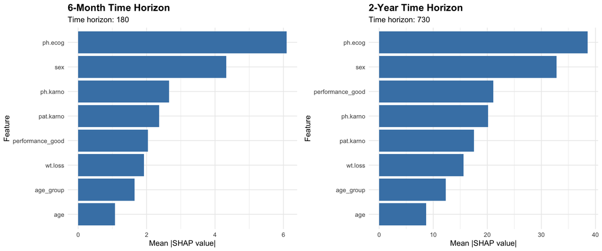

```r
# 6-month time horizon
shap_6mo <- ml4t2e_calculate_shap(
  pipeline = surv_pipeline,
  data = explain_data[1:30, ],
  time_horizon = 180,
  nsim = 50
)

# 2-year time horizon
shap_2yr <- ml4t2e_calculate_shap(
  pipeline = surv_pipeline,
  data = explain_data[1:30, ],
  time_horizon = 730,
  nsim = 50
)

# Compare importance at different horizons
library(gridExtra)
p1 <- ml4t2e_shap_importance(shap_6mo, max_features = 8, plot_type = "bar") +
  ggtitle("6-Month Time Horizon")
p2 <- ml4t2e_shap_importance(shap_2yr, max_features = 8, plot_type = "bar") +
  ggtitle("2-Year Time Horizon")

grid.arrange(p1, p2, ncol = 2)
```

# Example 2: Competing Risks Analysis

## Fit a Competing Risks Pipeline

```r
# Load BMT competing risks data
bmt_df <- get_bmt_competing_risks_data()

head(bmt_df)
```

```
##   sex   d   phase age status source  ftime
## 1   M ALL Relapse  48      2  BM+PB   0.67
## 2   F AML     CR2  23      1  BM+PB   9.50
## 3   M ALL     CR3   7      0  BM+PB 131.77
## 4   F ALL     CR2  26      2  BM+PB  24.03
## 5   F ALL     CR2  36      2  BM+PB   1.47
## 6   M ALL Relapse  17      2  BM+PB   2.23
```

```r
dim(bmt_df)
```

```
## [1] 177   7
```

```r
# Fit competing risks pipeline
cr_pipeline <- ml4t2e_fit_pipeline(
  data = bmt_df,
  analysis_type = "competing_risks",
  timevar = "ftime",
  eventvar = "status",
  models = c("FG", "cox", "rulefit", "xgboost", "ttah"),
  include_rf = FALSE,
  prediction_times = seq(0, 150, length.out = 40)
)

print(cr_pipeline)
```

```
## ml4time2event Pipeline
## ======================
## Analysis type : competing_risks
## Time variable : ftime
## Event variable: status
## Predictors    : 5 processed (5 original)
## Recipe        : minimal_data_recipe
## Observations  : 177
```

## Calculate SHAP Values for Competing Risks

```r
# Calculate SHAP values for competing risks
explain_cr <- bmt_df[1:40, ]

shap_cr <- ml4t2e_calculate_shap(
  pipeline = cr_pipeline,
  data = explain_cr,
  time_horizon = 100,  # 100-day expected time lost
  nsim = 50
)

print(shap_cr)
```

```
## ml4time2event SHAP Analysis
## ============================
## Analysis type  : competing_risks
## Time horizon   : 100
## Observations   : 40
## Features       : 5
## Baseline pred  : 34.709
##
## Features:
##   sex
##   d
##   phase
##   age
##   source
```

### Understanding Competing Risks Event Selection

**Important**: In competing risks analysis, the pipeline predicts **Event 1 (Relapse)** by default. The BMT dataset has:

- **Event 0**: Censored (no event)
- **Event 1**: Relapse (event of primary interest - **this is what we’re predicting**)
- **Event 2**: Treatment-related mortality (TRM)

```r
# Check event distribution
cat("Event counts in BMT data:\n")
```

```
## Event counts in BMT data:
```

```r
print(table(bmt_df$status))
```

```
##
##  0  1  2
## 46 56 75
```

```r
cat("\nAnalyzing: Event 1 (Relapse)\n")
```

```
##
## Analyzing: Event 1 (Relapse)
```

**Key insight**: Age can have **opposite effects** on different competing events: - Younger patients may have more aggressive disease → higher relapse risk - Older patients may be more frail → higher TRM risk but potentially lower relapse risk

Therefore, if you see negative SHAP values for older age, this may be **clinically correct** for relapse, even though it seems counterintuitive. Always interpret results in the context of the specific event being analyzed.

## Visualize Competing Risks SHAP Results

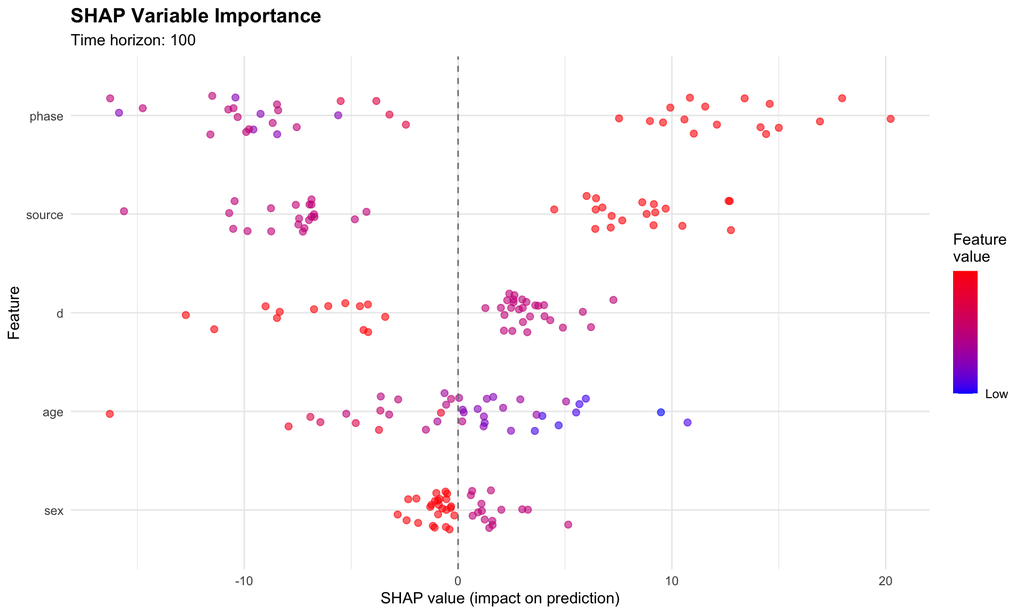

```r
# Variable importance
ml4t2e_shap_importance(shap_cr, max_features = 10)
```

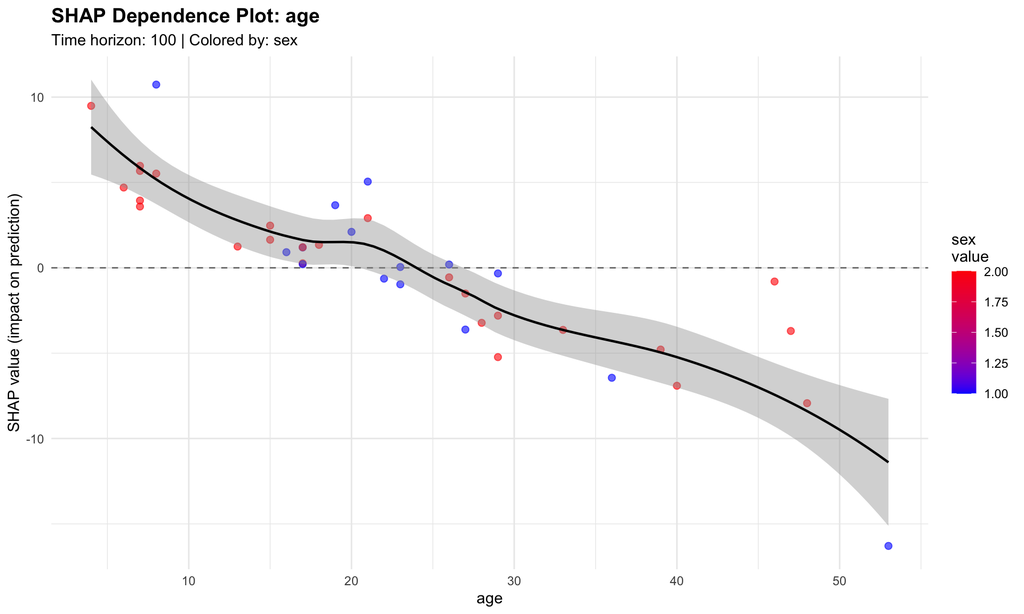

```r
# Dependence plot
ml4t2e_shap_dependence(shap_cr, feature = "age")
```

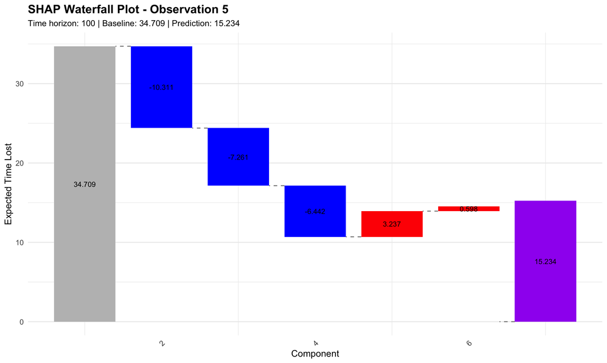

```r
# Waterfall for individual prediction
ml4t2e_shap_waterfall(shap_cr, obs_id = 5, max_features = 8)
```

# Practical Tips

## Choosing Time Horizon

The time horizon should be: 1. **Clinically meaningful**: e.g., 1-year, 5-year survival 2. **Within data range**: don’t exceed maximum observed time 3. **Relevant to decision**: match the timeframe of clinical decisions

## Computational Considerations

- **nsim**: Higher = more accurate but slower
  - Testing: 20-50
  - Production: 100-200
  - High precision: 500+
- **Sample size**: For large datasets, can calculate SHAP on a representative sample

  ```r
  # Sample up to 100 patients (or all if dataset is smaller)
  sample_size <- min(100, nrow(lung_df))
  sample_idx <- sample(nrow(lung_df), sample_size)
  shap_result <- ml4t2e_calculate_shap(
    pipeline = surv_pipeline,
    data = lung_df[sample_idx, ],
    time_horizon = 365,
    nsim = 30
  )
  ```

## Interpreting SHAP Values

- **Sign**:
  - Positive SHAP = increases expected time lost (worse outcome)
  - Negative SHAP = decreases expected time lost (better outcome)
  - **For competing risks**: Interpret relative to the specific event being analyzed (default: Event 1). Age effects can differ between competing events.
- **Magnitude**:
  - Larger |SHAP| = bigger impact
  - Units are same as prediction (expected time lost in days)
- **Feature interactions**:
  - Look at dependence plots colored by other features
  - Non-linear patterns indicate interactions

## Feature Engineering

SHAP values work on **raw features** (before preprocessing). The pipeline automatically: 1. Takes raw data 2. Applies preprocessing (imputation, encoding, scaling) 3. Generates predictions 4. Calculates SHAP values relative to raw features

This means SHAP values directly explain the original variables, which is important for interpretability.

# Advanced: Custom Analysis

## Identify High-Risk Patients

```r
# Find patients with highest predicted time lost
high_risk_idx <- order(shap_surv$predictions, decreasing = TRUE)[1:5]

cat("Top 5 high-risk patients:\n")
```

```
## Top 5 high-risk patients:
```

```r
for (i in high_risk_idx) {
  cat(sprintf("Patient %d: Expected time lost = %.1f days\n",
              i, shap_surv$predictions[i]))
}
```

```
## Patient 30: Expected time lost = 226.7 days
## Patient 28: Expected time lost = 220.0 days
## Patient 32: Expected time lost = 183.0 days
## Patient 46: Expected time lost = 173.1 days
## Patient 39: Expected time lost = 165.0 days
```

```r
# Explain why they're high risk
for (i in high_risk_idx[1:2]) {
  print(ml4t2e_shap_waterfall(shap_surv, obs_id = i, max_features = 8))
}
```

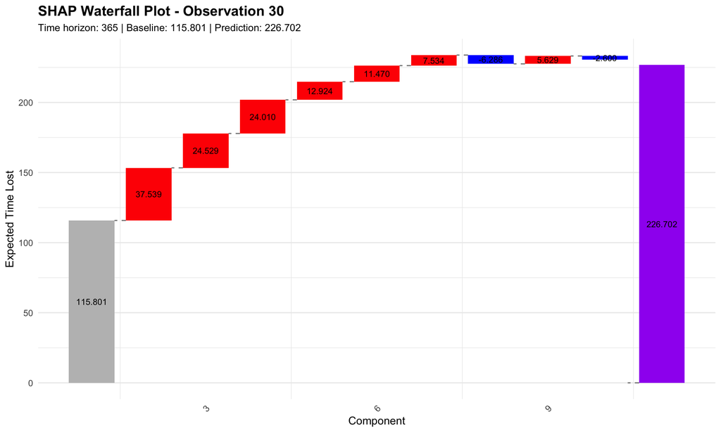

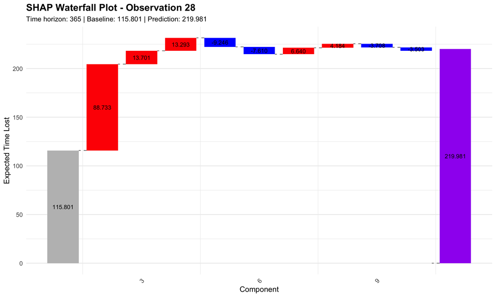

## Feature Interactions

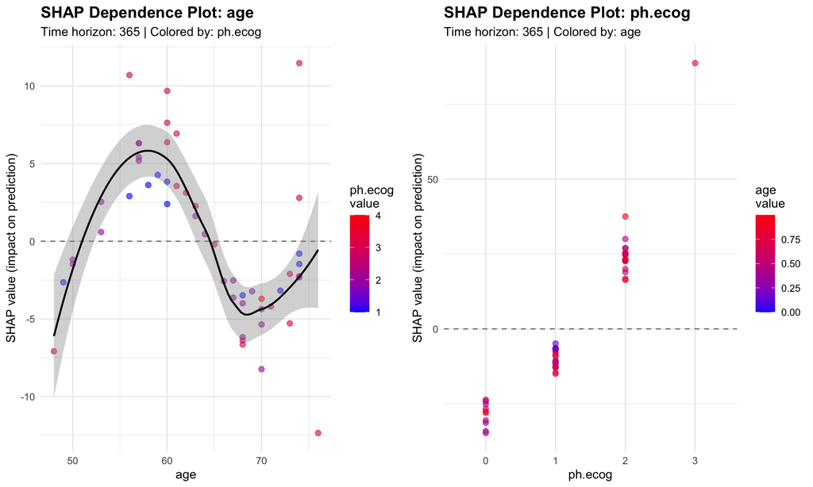

```r
# Examine how two features interact
# Create a grid of age and performance values
if (all(c("age", "ph.ecog") %in% colnames(lung_df))) {

  # Dependence plot shows interactions
  p1 <- ml4t2e_shap_dependence(shap_surv, feature = "age", color_by = "ph.ecog")
  p2 <- ml4t2e_shap_dependence(shap_surv, feature = "ph.ecog", color_by = "age")

  grid.arrange(p1, p2, ncol = 2)
}
```

## Export SHAP Values for Further Analysis

```r
# SHAP values are stored as a matrix
shap_matrix <- shap_surv$shap_values
head(shap_matrix)
```

```
##            age       sex    ph.ecog   ph.karno  pat.karno  meal.cal  wt.loss
## [1,] -2.250655  9.871871 -12.618584 -10.031574 -17.066453 -2.377074 3.248648
## [2,] -3.479507 11.319118 -30.553901 -11.960027  -7.601270 -2.928833 4.486965
## [3,]  2.905953 12.361070 -31.327611  -7.691987  -9.397819 -1.223400 2.115907
## [4,]  6.314582 10.772873 -11.218511 -17.245843  26.054940 -4.254657 3.245197
## [5,]  2.399957 10.630030 -26.693599 -13.870581 -12.273660 -1.631055 5.241773
## [6,] -2.317821 13.639339  -7.344802   1.198788  -1.954258  4.675381 3.580928
##      age_group performance_good
## [1,]  3.397738         7.216715
## [2,]  5.940101         8.936487
## [3,] -6.161895         9.643331
## [4,] -3.523237        11.891889
## [5,] -5.415706         6.412878
## [6,]  2.883311        -6.052341
```

```r
# Can be exported to CSV
# write.csv(shap_matrix, "shap_values.csv")

# Or combined with predictions
results_df <- data.frame(
  observation = 1:nrow(shap_matrix),
  prediction = shap_surv$predictions,
  shap_surv$shap_values
)

head(results_df)
```

```
##   observation prediction       age       sex    ph.ecog   ph.karno  pat.karno
## 1           1   95.37122 -2.250655  9.871871 -12.618584 -10.031574 -17.066453
## 2           2   92.24380 -3.479507 11.319118 -30.553901 -11.960027  -7.601270
## 3           3   82.10002  2.905953 12.361070 -31.327611  -7.691987  -9.397819
## 4           4  140.68723  6.314582 10.772873 -11.218511 -17.245843  26.054940
## 5           5   82.75984  2.399957 10.630030 -26.693599 -13.870581 -12.273660
## 6           6  109.81457 -2.317821 13.639339  -7.344802   1.198788  -1.954258
##    meal.cal  wt.loss age_group performance_good
## 1 -2.377074 3.248648  3.397738         7.216715
## 2 -2.928833 4.486965  5.940101         8.936487
## 3 -1.223400 2.115907 -6.161895         9.643331
## 4 -4.254657 3.245197 -3.523237        11.891889
## 5 -1.631055 5.241773 -5.415706         6.412878
## 6  4.675381 3.580928  2.883311        -6.052341
```

# Summary

This vignette demonstrated:

1. **Calculating SHAP values** for survival and competing risks models
2. **Variable importance plots** to identify key features
3. **Dependence plots** to understand feature effects and interactions
4. **Waterfall plots** to explain individual predictions
5. **Practical considerations** for time horizon selection and computation

SHAP analysis provides powerful tools for understanding and explaining time-to-event model predictions, which is essential for clinical applications and model validation.